# Modeling Choices #02. T-distribution

Joon-Ho Lee (joonho@berkeley.edu)

February 23, 2020

# 1 The Rubin (1981) model with $t$ shrinkage prior

Consider $K$ study sites in which researchers perform the same interventions and measure the same outcomes. Each site, indexed by $k$, estimates a treatment effect $\tau_k$ averaged across individuals in the site. The sites don’t report $\{\tau_k\}^{K}_{k=1}$: instead, they report $\{\hat{\tau}_k\}^{K}_{k=1}$. Some of the observed variation in $\{\hat{\tau}_k\}^{K}_{k=1}$ is sampling variation, yet there is likely to be some genuine variation in effects across settings, often defined as $\sigma_{\tau}^{2} = \text{var}(\tau_{k})$.

Rubin (1981) considers a case in which the analyst has access to a set of estimated effects $\{\hat{\tau}_k\}^{K}_{k=1}$ and estimates of the associated sampling errors $\{\hat{se}_{\tau_k}\}^{K}_{k=1}$. Rubin specifies a relationship between the observed estimates and the unobserved $\{\tau_k\}^{K}_{k=1}$, and in addition spcifies a relationship between $\{\tau_k\}^{K}_{k=1}$ and the aggregate parameters $(\tau, \sigma_{\tau}^2)$). The Rubin (1981) model has a hierarchical likelihood in which each site has own treatment effect parameter, $\tau_k$, but these effects are all drawn from a common distribution governed by $(\tau, \sigma_{\tau}^2)$ as follows:

$$\hat{\tau}_{k} \sim N(\tau_{k}, \hat{se}_{k}^2) \quad \forall k,$$
$$\tau_{k} \sim t_{\nu = 5}(\tau, \sigma_{\tau}^2) \quad \forall k,$$

where $\mathbb{E}(\tau_k) = \tau$ and $\text{var}(\tau_k) = \sigma_{\tau}^{2} \cdot \frac{\nu}{\nu - 2}$. A $t$ prior for a normal mean provides a reasonable posterior even if the data and prior disagree. A $t$ prior provides similar shrinkage to a normal prior when the data and prior agree, but provides little shrinkage when the data and prior disagree. By using the $t$ shrinkage prior, we expect to go beyond normality to add heavy tails.

# 2 Generate simulated data from a $t_{\nu = 5}$ distribution

$G$ will be simulated to follow a student $t$ distribution with degrees of freedom $\nu = 5$, mean 0, and variance 1. We first set our simulation parameters to reflect a range of data informativeness and heterogeneity among sites with respect to variance.

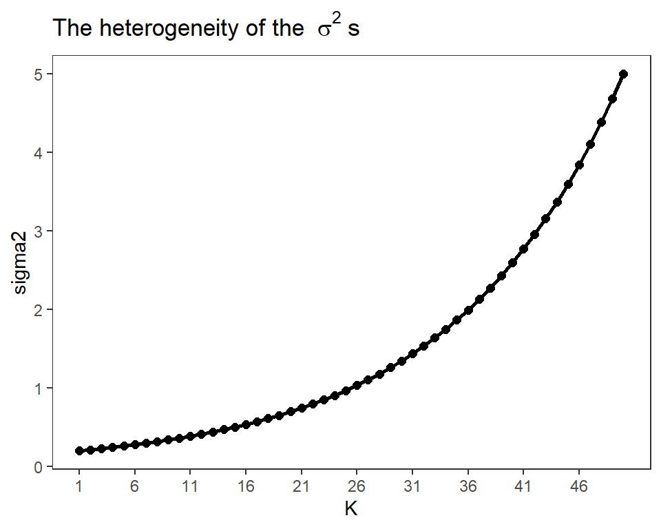

```r
### Example settings
n <- 50; rgt <- 1; rsr <- 5

### Set maximum and minimum within-site variances
sigma2max <- rgt*rsr
sigma2min <- sigma2max/(rsr^2)

### Generate within-site variances (sds) for K sites
sigma2 <- exp(seq(from = log(sigma2min), to = log(sigma2max), length = n))
sd <- sqrt(sigma2)

### Plot within-site variances
df_temp <- tibble(sigma2, sd) %>%
  mutate(K = 1:n())

ggplot(data = df_temp, aes(x = K, y = sigma2)) +
  geom_point(size = 2.0) + geom_path(size = 1.0) +
  scale_x_continuous(breaks = seq(1, n, by = 5)) +
  labs(title = bquote("The heterogeneity of the " ~ sigma^2 ~"s")) +
  theme_preset
```

The **R** function that follows simulates a dataset conforming to the $t_{\nu = 5}$ model.

```r
### Define a function to generate random draws from T-distribution with df = 5 (nu)
GenerateT <- function(n, rgt, rsr, nu) {

  ### Generate within-site variances (sds) for K sites
  sigma2max <- rgt*rsr
  sigma2min <- sigma2max/(rsr^2)
  sigma2 <- exp(seq(from = log(sigma2min), to = log(sigma2max), length = n))
  sd <- sqrt(sigma2)

  ## Mean of T-distribution
  mn <- 0

  ## Generate data object
  data_obj <- list()
  data_obj$tau_k <- rt(n, nu)*sqrt((nu - 2)/nu)
  data_obj$tau_k_hat <- rnorm(n, data_obj$tau_k, sd)
  data_obj$se_k2 <- sigma2
  return(data_obj)
}

### Generate sample draws from the T model
df_G <- GenerateT(n = 50, rgt = 1, rsr = 5, nu = 5) %>%
  data.frame() %>%
  rownames_to_column("K") %>%
  mutate_at(.vars = c("K"), .funs = as.numeric)

head(df_G)
```

```
##   K       tau_k  tau_k_hat     se_k2
## 1 1 -0.38085511 -0.7302269 0.2000000
## 2 2  0.35410301 -0.3577678 0.2135794
## 3 3 -0.36716973 -0.6132912 0.2280808
## 4 4 -1.05299895 -1.7129050 0.2435668
## 5 5  0.06788843  0.8491429 0.2601043
## 6 6  0.04031619 -0.4401735 0.2777646
```

Next, we compare the observed estimates ($\hat{\tau}_k$) to the true distribution of $\tau_k$.

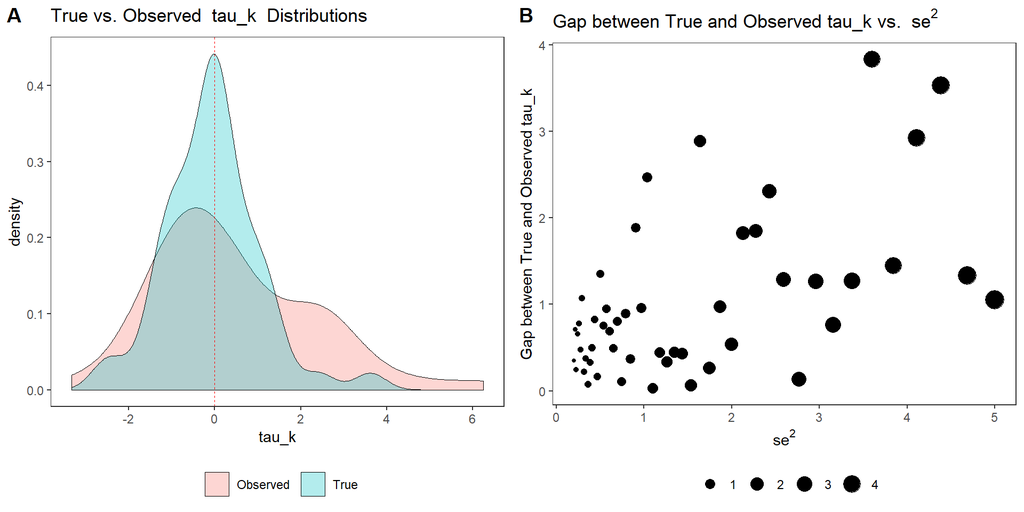

```r
### Define a function to generate plot
plot_compare_true_obs <- function(df_G){

  # Compare the true distribution (tau_k) to the observed data (tau_k_hat)
  df_plot <- df_G %>%
    select(tau_k, tau_k_hat) %>%
    rename(True = tau_k, Observed = tau_k_hat) %>%
    gather(key = variable, value = value)

  p1 <- ggplot(data = df_plot, aes(x = value, group = variable, fill = variable)) +
      geom_density(position = "identity", size = 0.1, alpha = 0.3) +
      geom_vline(aes(xintercept = 0), size = 0.3, color = "red", linetype = "dashed") +
      labs(title = bquote("True vs. Observed " ~ tau_k ~" Distributions"),
           x = expression(tau_k)) + theme_preset

  # Compare point estimates by sigma_k
  p2 <- ggplot(data = df_G %>% mutate(gap = abs(tau_k_hat - tau_k)),
               aes(x = se_k2, y = gap)) +
      geom_point(aes(size = se_k2)) +
    labs(title = bquote("Gap between True and Observed tau_k vs. " ~ se^2),
         y = bquote("Gap between True and Observed tau_k"),
         x = expression(se^2)) + theme_preset

  # Combine the two plots
  p_grid <- plot_grid(p1, p2, labels = "AUTO")
  return(p_grid)
}

plot_compare_true_obs(df_G)
```

The empirical distribution function (EDF) of the observed $\hat{\tau}_k$ is overdispersed due to the uncertainty of the observed data, $\hat{se}_k^2$. The discrepancy between true and observed $\tau_k$s tends to be larger for the sites with larger $\hat{se}_k^2$.

# 3 Parameter estimation using **Stan**

First, we obtain simulates from the posterior of a $t_{\nu = 5}$ model using **Stan**. The **Stan** program for the Rubin (1981) model with $t$ shrinkage prior is provided below:

```
data {
  int<lower = 0> K;         // number of sites
  real tau_hat_k[K];        // estimated treatment effects
  real<lower=0> se_k[K];    // s.e. of effect estimates
}
parameters {
  real tau;
  real<lower=0> sigma_tau;
  real tau_k[K];
}
model {
  sigma_tau ~ uniform(0, 1000);           // vague prior
  tau ~ normal(0, 1000);                  // vague prior
  tau_k ~ student_t(5, tau, sigma_tau);   // second-level normal
  tau_hat_k ~ normal(tau_k, se_k);        // third-level normal
}
generated quantities{
  real predicted_tau_k;
  predicted_tau_k = student_t_rng(5, tau, sigma_tau);  //mixed predictive
}
```

Note that the Rubin model assumes $t_{\nu = 5}$ distribution of effects across sites. The Rubin model performs univariate shrinkage so we will not need to specify a hyper-correlation prior. But we still need to specify hyperpriors on the hyper-mean $\tau$ and hyper-SD $\sigma_{\tau}$:

- For $\tau$, the prior is $\text{N}(0, 1000)$. This is a very weak prior which does little regularization, centered at zero. It assumes that causal effects should not be thought of as large unless data contains evidence to the contrary.
- For $\sigma_{\tau}$, the prior is $\text{Uniform}(0, 1000)$, which is also a very weak prior.

The model specified in the Stan program is fit to the simulated data:

```r
### Collect data into a list format suitable for Stan
stan_data <- list(K = length(df_G$K),
                  tau_hat_k = df_G$tau_k_hat,
                  se_k = sqrt(df_G$se_k2))

### Compile and run the stan model
fit_rubin<- stan(file = "rubin_model_02_T5.stan",
                 data = stan_data,
                 iter = 1000, chains = 4)
```

The posterior means and standard deviations of the parameters can be displayed as follows:

```r
print(fit_rubin, probs = c(0.1, 0.5, 0.9), digits = 3)
```

```
## Inference for Stan model: rubin_model_02_T5.
## 4 chains, each with iter=1000; warmup=500; thin=1;
## post-warmup draws per chain=500, total post-warmup draws=2000.
##
##                    mean se_mean    sd     10%     50%     90% n_eff  Rhat
## tau               0.218   0.006 0.254  -0.096   0.209   0.543  1811 1.000
## sigma_tau         1.201   0.008 0.227   0.927   1.187   1.499   812 0.999
## tau_k[1]         -0.616   0.009 0.428  -1.174  -0.606  -0.068  2313 0.999
## tau_k[2]         -0.278   0.009 0.431  -0.833  -0.266   0.265  2178 1.000
## tau_k[3]         -0.505   0.009 0.451  -1.061  -0.500   0.067  2436 1.000
## tau_k[4]         -1.462   0.011 0.468  -2.055  -1.458  -0.856  1922 0.999
## tau_k[5]          0.735   0.009 0.463   0.155   0.732   1.332  2546 0.999
## tau_k[6]         -0.336   0.010 0.485  -0.980  -0.325   0.268  2377 1.000
## tau_k[7]          4.385   0.012 0.538   3.696   4.368   5.077  2143 1.001
## tau_k[8]          0.049   0.011 0.504  -0.595   0.056   0.687  2275 0.999
## tau_k[9]          1.053   0.011 0.548   0.353   1.054   1.772  2277 0.999
## tau_k[10]        -0.856   0.011 0.541  -1.569  -0.857  -0.181  2380 0.999
## tau_k[11]        -1.436   0.013 0.595  -2.214  -1.399  -0.684  1984 1.000
## tau_k[12]        -0.301   0.012 0.577  -1.020  -0.279   0.402  2435 1.000
## tau_k[13]         1.842   0.012 0.634   1.057   1.816   2.654  2719 0.999
## tau_k[14]        -0.660   0.012 0.623  -1.468  -0.653   0.122  2553 0.998
## tau_k[15]         1.850   0.014 0.685   0.968   1.847   2.728  2358 1.000
## tau_k[16]        -2.729   0.015 0.725  -3.666  -2.740  -1.793  2425 1.001
## tau_k[17]         0.716   0.012 0.647  -0.124   0.707   1.579  2873 0.999
## tau_k[18]        -0.881   0.015 0.694  -1.784  -0.870  -0.020  2050 0.999
## tau_k[19]         0.482   0.015 0.659  -0.318   0.460   1.325  2017 0.999
## tau_k[20]         1.642   0.018 0.766   0.689   1.618   2.663  1835 0.999
## tau_k[21]         0.406   0.016 0.711  -0.470   0.395   1.284  2088 1.000
## tau_k[22]         0.269   0.016 0.693  -0.613   0.259   1.153  1937 1.001
## tau_k[23]        -0.442   0.016 0.779  -1.402  -0.423   0.515  2383 1.001
## tau_k[24]         1.225   0.017 0.814   0.177   1.185   2.265  2308 0.998
## tau_k[25]        -0.071   0.016 0.785  -1.074  -0.059   0.895  2459 1.001
## tau_k[26]         2.268   0.022 0.967   1.017   2.255   3.555  1997 0.999
## tau_k[27]        -0.002   0.016 0.808  -1.037   0.016   0.969  2713 1.000
## tau_k[28]         0.166   0.016 0.813  -0.844   0.141   1.196  2524 1.000
## tau_k[29]        -0.528   0.018 0.860  -1.636  -0.508   0.553  2328 1.000
## tau_k[30]         0.368   0.017 0.862  -0.704   0.342   1.470  2497 1.001
## tau_k[31]        -0.501   0.019 0.899  -1.666  -0.478   0.585  2151 1.000
## tau_k[32]         0.062   0.018 0.846  -1.046   0.066   1.140  2297 0.999
## tau_k[33]         1.586   0.023 1.072   0.283   1.505   3.011  2181 0.999
```

[output cut: 9 more lines]

```
## tau_k[43]         0.177   0.022 1.036  -1.125   0.201   1.378  2296 1.002
## tau_k[44]        -0.139   0.022 1.088  -1.496  -0.099   1.190  2439 0.999
## tau_k[45]         2.951   0.048 1.716   0.873   2.763   5.193  1260 1.003
## tau_k[46]         0.001   0.021 1.124  -1.441   0.007   1.369  2741 0.999
## tau_k[47]         0.910   0.027 1.203  -0.496   0.828   2.437  1983 0.998
## tau_k[48]         1.198   0.031 1.266  -0.274   1.093   2.884  1630 0.999
## tau_k[49]         0.881   0.027 1.188  -0.528   0.801   2.391  1924 1.001
## tau_k[50]        -0.044   0.029 1.233  -1.552  -0.009   1.432  1862 0.999
## predicted_tau_k   0.165   0.034 1.561  -1.609   0.200   1.882  2057 1.002
## lp__            -64.976   0.249 6.155 -73.156 -64.660 -57.404   610 1.003
##
## Samples were drawn using NUTS(diag_e) at Mon Feb 24 21:29:13 2020.
## For each parameter, n_eff is a crude measure of effective sample size,
## and Rhat is the potential scale reduction factor on split chains (at
## convergence, Rhat=1).
```

Before interpreting the results, it is necessary to check that the chains have converged for each parameter. The $\hat{R}$ statistics shown in the rightmost column of the model summary are all less than 1.1. Also the effective sample size estimates are sufficient for inference. Thus it seems that **Stan** has produced an adequate approximation of the posterior.

Then, we extract posterior samples and save it for later comparison with estimates from `hhsim` package.

```r
### Extract posterior samples
posterior <- as.data.frame(fit_rubin) %>%
  mutate(Type = "Stan") %>%
  dplyr::select(Type, everything())
dim(posterior)
```

```
## [1] 2000   55
```

# 4 Parameter estimation using the `hhsim` package

Second, we obtain simulates from the posterior of a $t_{\nu = 5}$ model using the `hhsim` package. The **Stan** program above runs 4 chains with a burn-in period of 500 iterations followed by 500 additional iterations per chain. Since the `hhsim` package does not use separate chains, we set the number of MCMC and burn-in iterations to 2,000, respectively, in order for the total iterations to be the same with those of the **Stan** program.

```r
### Set numbers of iterations
nmcmc <- 2000    # number of MCMC iterations per each model fit
nburn <- 2000    # burn-in iterations to discard at each round
nmcmcall <- nmcmc + nburn

### Extract vectors of observed tau_ks and their SEs
Y <- df_G$tau_k_hat   # a vector of observed tau_ks
sigma2 <- df_G$se_k2  # a vector of known SEs
nDraws <- nmcmcall    # number of MCMC draws

### Estimate the T5 model using hhsim package
outp <- GaussianT(Y, sigma2, nDraws, nu = 5)

### Define a function to tidy up the output object
get_posterior_sample <- function(output = outp, nburn = 100, nmcmcall = 600){

  # (1) Tidy up the "theta" output object
  df_theta <- outp[["theta"]] %>%
    unlist() %>%
    matrix(nrow = length(outp[["theta"]]), byrow = TRUE) %>%
    data.frame() %>%
    slice(c((nburn + 1):nmcmcall))  # throw away burn-ins
  colnames(df_theta) <- paste0("tau_k[", seq(ncol(df_theta)), "]")

  # (2) Tidy up the "tau" and "sigma_tau" output objects
  df_hyperparm <- outp[["m"]] %>%
    cbind.data.frame(outp[["tau2"]]) %>%
    slice(c((nburn + 1):nmcmcall))  # throw away burn-ins
  colnames(df_hyperparm) <- c("tau", "sigma_tau")

  ### Return the resulting object
  cbind.data.frame(df_hyperparm, df_theta)
}

### Save posterior samples
posterior_hhsim <- get_posterior_sample(outp, nburn, nmcmcall) %>%
  mutate(Type = "hhsim") %>% dplyr::select(Type, everything())
```

# 5 Comparison of posterior samples obtained from **Stan** and `hhsim`

Would the **Stan** program and `hhsim` package lead to the same estimates? We start from combining the two data frames containing posterior samples:

```r
### Combine two dataframes: Stan and hhsim
df_combine <- posterior %>%
  dplyr::select(-predicted_tau_k, -lp__) %>%
  bind_rows(posterior_hhsim) %>%
  mutate(Type = factor(Type, levels = c("Stan", "hhsim")))
```

## 5.1 Hyperparameters $\tau$ and $\sigma_{\tau}$

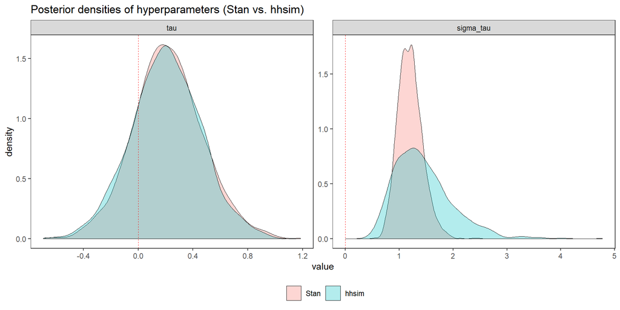

```r
### Generate a dataframe to plot
df_plot <- df_combine %>%
  dplyr::select(Type, tau, sigma_tau) %>%
  gather(key = variable, value = value, -Type) %>%
  mutate(variable = factor(variable, levels = c("tau", "sigma_tau")))

### Define a function to generate plot
plot_compare_density <- function(df_plot, title = title){
  ggplot(data = df_plot, aes(x = value, group = Type, fill = Type)) +
    geom_density(position = "identity", size = 0.1, alpha = 0.3) +
    geom_vline(aes(xintercept = 0), size = 0.3, color = "red", linetype = "dashed") +
    labs(title = title) + theme_preset
}

plot_compare_density(df_plot, title = "Posterior densities of hyperparameters (Stan vs. hhsim)") +
  facet_wrap(~ variable, scales = "free")
```

## 5.2 Empirical distribution function (EDF) estimates for $\tau_{k}$s

```r
df_temp <- df_combine %>%
  dplyr::select(Type, contains("tau_k[")) %>%
  gather(key = variable, value = value, -Type) %>%
  group_by(Type, variable) %>%
  summarise(mean = mean(value, na.rm = TRUE),
            sd = sd(value, na.rm = TRUE)) %>%
  mutate(id = as.numeric(str_extract(variable, "\\d+"))) %>%
  arrange(id, Type)

head(df_temp, 10)
```

```
## # A tibble: 10 x 5
## # Groups:   Type [2]
##    Type  variable   mean    sd    id
##    <fct> <chr>     <dbl> <dbl> <dbl>
##  1 Stan  tau_k[1] -0.616 0.428     1
##  2 hhsim tau_k[1] -0.592 0.421     1
##  3 Stan  tau_k[2] -0.278 0.431     2
##  4 hhsim tau_k[2] -0.267 0.428     2
##  5 Stan  tau_k[3] -0.505 0.451     3
##  6 hhsim tau_k[3] -0.485 0.438     3
##  7 Stan  tau_k[4] -1.46  0.468     4
##  8 hhsim tau_k[4] -1.47  0.486     4
##  9 Stan  tau_k[5]  0.735 0.463     5
## 10 hhsim tau_k[5]  0.740 0.473     5
```

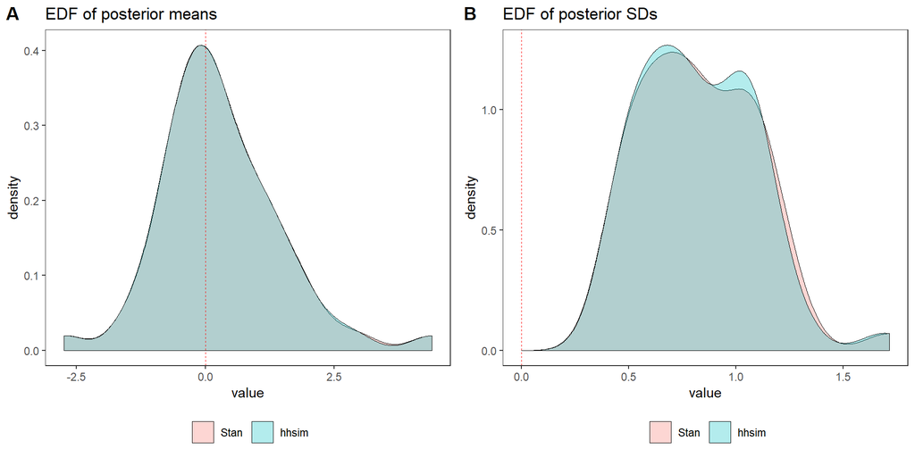

```r
p1 <- plot_compare_density(df_temp %>% rename(value = mean), title = "EDF of posterior means")
p2 <- plot_compare_density(df_temp %>% rename(value = sd), title = "EDF of posterior SDs")
plot_grid(p1, p2, labels = "AUTO")
```

## 5.3 Site-specific individual effect estimates $\tau_{k}$s

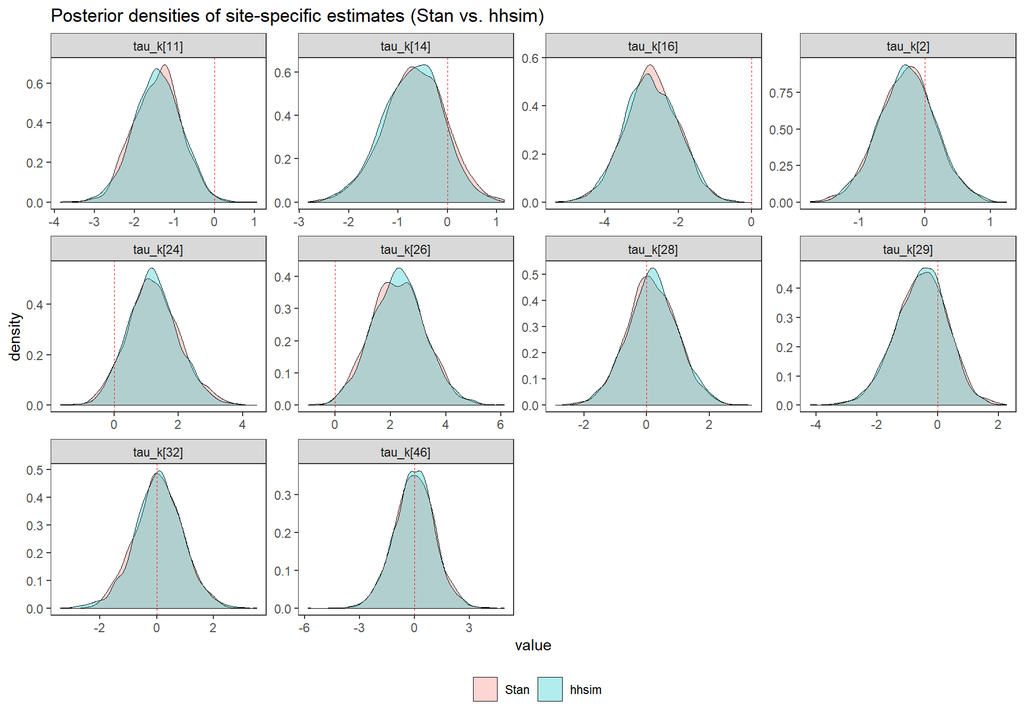

```r
### Compare densities: site-specific estiamtes
set.seed(12345)
rand_var <- paste0("tau_k[", sample(1:50, 10, replace = FALSE), "]")

df_plot <- df_combine %>%
  dplyr::select(Type, rand_var) %>%
  gather(key = variable, value = value, -Type)

title <- "Posterior densities of site-specific estimates (Stan vs. hhsim)"
plot_compare_density(df_plot, title = title) +
  facet_wrap(~ variable, scales = "free")
```

# References

Rubin, Donald B. 1981. “Estimation in Parallel Randomized Experiments.” *Journal of Educational Statistics* 6 (4): 377–401.